# Optimal Treatment Analysis

## Outcome Variable

**Outcome Variable:** haz

## Predictor Variables

**Intervention Variable:** mwtkg

**Adjustment Set:**

- arm
- W_mage
- meducyrs
- feducyrs
- single
- brthmon
- W_parity
- delta_W_mage
- delta_meducyrs
- delta_feducyrs
- delta_single
- delta_brthmon
- delta_W_parity

## Stratifying Variables

The analysis was stratified on these variable(s):

- agecat
- studyid
- country

## Data Summary

| agecat | studyid | country | mwtkg | n_cell | n |
| --- | --- | --- | --- | --- | --- |
| Birth | JiVitA-3 | BANGLADESH | >=58 kg | 500 | 22432 |
| Birth | JiVitA-3 | BANGLADESH | <52 kg | 20479 | 22432 |
| Birth | JiVitA-3 | BANGLADESH | [52-58) kg | 1453 | 22432 |
| Birth | MAL-ED | BANGLADESH | >=58 kg | 38 | 222 |
| Birth | MAL-ED | BANGLADESH | <52 kg | 143 | 222 |
| Birth | MAL-ED | BANGLADESH | [52-58) kg | 41 | 222 |
| Birth | MAL-ED | BRAZIL | >=58 kg | 34 | 64 |
| Birth | MAL-ED | BRAZIL | <52 kg | 15 | 64 |
| Birth | MAL-ED | BRAZIL | [52-58) kg | 15 | 64 |
| Birth | MAL-ED | INDIA | >=58 kg | 6 | 43 |
| Birth | MAL-ED | INDIA | <52 kg | 29 | 43 |
| Birth | MAL-ED | INDIA | [52-58) kg | 8 | 43 |
| Birth | MAL-ED | NEPAL | >=58 kg | 9 | 27 |
| Birth | MAL-ED | NEPAL | <52 kg | 8 | 27 |
| Birth | MAL-ED | NEPAL | [52-58) kg | 10 | 27 |
| Birth | MAL-ED | PERU | >=58 kg | 83 | 226 |
| Birth | MAL-ED | PERU | <52 kg | 84 | 226 |
| Birth | MAL-ED | PERU | [52-58) kg | 59 | 226 |
| Birth | MAL-ED | SOUTH AFRICA | >=58 kg | 69 | 101 |
| Birth | MAL-ED | SOUTH AFRICA | <52 kg | 10 | 101 |
| Birth | MAL-ED | SOUTH AFRICA | [52-58) kg | 22 | 101 |
| Birth | MAL-ED | TANZANIA, UNITED REPUBLIC OF | >=58 kg | 47 | 122 |
| Birth | MAL-ED | TANZANIA, UNITED REPUBLIC OF | <52 kg | 45 | 122 |
| Birth | MAL-ED | TANZANIA, UNITED REPUBLIC OF | [52-58) kg | 30 | 122 |
| Birth | NIH-Birth | BANGLADESH | >=58 kg | 80 | 608 |
| Birth | NIH-Birth | BANGLADESH | <52 kg | 441 | 608 |
| Birth | NIH-Birth | BANGLADESH | [52-58) kg | 87 | 608 |
| Birth | NIH-Crypto | BANGLADESH | >=58 kg | 186 | 729 |
| Birth | NIH-Crypto | BANGLADESH | <52 kg | 395 | 729 |
| Birth | NIH-Crypto | BANGLADESH | [52-58) kg | 148 | 729 |

[output cut: 105 more lines]

The following strata were considered:

- agecat: 24 months, studyid: JiVitA-3, country: BANGLADESH
- agecat: 24 months, studyid: LCNI-5, country: MALAWI
- agecat: 24 months, studyid: MAL-ED, country: BANGLADESH
- agecat: 24 months, studyid: MAL-ED, country: BRAZIL
- agecat: 24 months, studyid: MAL-ED, country: INDIA
- agecat: 24 months, studyid: MAL-ED, country: NEPAL
- agecat: 24 months, studyid: MAL-ED, country: PERU
- agecat: 24 months, studyid: MAL-ED, country: SOUTH AFRICA
- agecat: 24 months, studyid: MAL-ED, country: TANZANIA, UNITED REPUBLIC OF
- agecat: 24 months, studyid: NIH-Birth, country: BANGLADESH
- agecat: 24 months, studyid: NIH-Crypto, country: BANGLADESH
- agecat: 24 months, studyid: PROBIT, country: BELARUS
- agecat: 24 months, studyid: PROVIDE, country: BANGLADESH
- agecat: 24 months, studyid: TanzaniaChild2, country: TANZANIA, UNITED REPUBLIC OF
- agecat: 24 months, studyid: ZVITAMBO, country: ZIMBABWE
- agecat: 6 months, studyid: JiVitA-3, country: BANGLADESH
- agecat: 6 months, studyid: LCNI-5, country: MALAWI
- agecat: 6 months, studyid: MAL-ED, country: BANGLADESH
- agecat: 6 months, studyid: MAL-ED, country: BRAZIL
- agecat: 6 months, studyid: MAL-ED, country: INDIA
- agecat: 6 months, studyid: MAL-ED, country: NEPAL
- agecat: 6 months, studyid: MAL-ED, country: PERU
- agecat: 6 months, studyid: MAL-ED, country: SOUTH AFRICA
- agecat: 6 months, studyid: MAL-ED, country: TANZANIA, UNITED REPUBLIC OF
- agecat: 6 months, studyid: NIH-Birth, country: BANGLADESH
- agecat: 6 months, studyid: NIH-Crypto, country: BANGLADESH
- agecat: 6 months, studyid: PROBIT, country: BELARUS
- agecat: 6 months, studyid: PROVIDE, country: BANGLADESH
- agecat: 6 months, studyid: SAS-CompFeed, country: INDIA
- agecat: 6 months, studyid: TanzaniaChild2, country: TANZANIA, UNITED REPUBLIC OF
- agecat: 6 months, studyid: ZVITAMBO, country: ZIMBABWE
- agecat: Birth, studyid: JiVitA-3, country: BANGLADESH
- agecat: Birth, studyid: MAL-ED, country: BANGLADESH
- agecat: Birth, studyid: MAL-ED, country: BRAZIL
- agecat: Birth, studyid: MAL-ED, country: INDIA
- agecat: Birth, studyid: MAL-ED, country: NEPAL
- agecat: Birth, studyid: MAL-ED, country: PERU
- agecat: Birth, studyid: MAL-ED, country: SOUTH AFRICA
- agecat: Birth, studyid: MAL-ED, country: TANZANIA, UNITED REPUBLIC OF
- agecat: Birth, studyid: NIH-Birth, country: BANGLADESH
- agecat: Birth, studyid: NIH-Crypto, country: BANGLADESH
- agecat: Birth, studyid: PROBIT, country: BELARUS
- agecat: Birth, studyid: PROVIDE, country: BANGLADESH
- agecat: Birth, studyid: SAS-CompFeed, country: INDIA
- agecat: Birth, studyid: ZVITAMBO, country: ZIMBABWE

### Dropped Strata

Some strata were dropped due to rare outcomes:

- agecat: 24 months, studyid: TanzaniaChild2, country: TANZANIA, UNITED REPUBLIC OF

## Methods Detail

We’re interested in the causal parameters $E[Y_a]$ for all values of $a \in \mathcal{A}$. These parameters represent the mean outcome if, possibly contrary to fact, we intervened to set all units to have $A=a$. Under the randomization and positivity assumptions, these are identified by the statistical parameters $\psi_a=E_W[E_{Y|A,W}(Y|A=a,W)]$. In addition, we’re interested in the mean of $Y$, $E[Y]$ under no intervention (the observed mean). We will estimate these parameters by using SuperLearner to fit the relevant likelihood factors – $E_{Y|A,W}(Y|A=a,W)$ and $p(A=a|W)$, and then updating our likelihood fit using a joint TMLE.

For unadjusted analyses ($W=\{\}$), initial likelihoods were estimated using Lrnr_glm to estimate the simple $E(Y|A)$ and Lrnr_mean to estimate $p(A)$. For adjusted analyses, a small library containing Lrnr_glmnet, Lrnr_xgboost, and Lrnr_mean was used.

Having estimated these parameters, we will then use the delta method to estimate relative risks and attributable risks relative to a prespecified baseline level of $A$.

[output not shown]

# Results Detail

## Results Plots

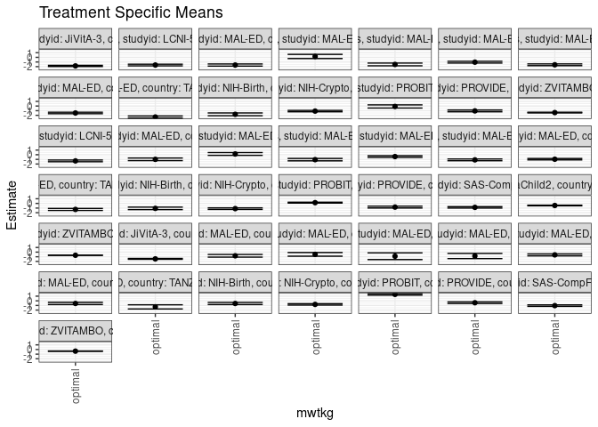

## Results Table

### Parameter: TSM

| agecat | studyid | country | intervention_level | baseline_level | estimate | ci_lower | ci_upper |
| --- | --- | --- | --- | --- | --- | --- | --- |
| Birth | JiVitA-3 | BANGLADESH | optimal | observed | -1.4570312 | -1.5515502 | -1.3625122 |
| Birth | MAL-ED | BANGLADESH | optimal | observed | -0.7914295 | -1.0766713 | -0.5061876 |
| Birth | MAL-ED | BRAZIL | optimal | observed | -0.4841995 | -0.8787074 | -0.0896917 |
| Birth | MAL-ED | INDIA | optimal | observed | -0.8842728 | -1.6100084 | -0.1585372 |
| Birth | MAL-ED | NEPAL | optimal | observed | -0.8352977 | -1.3994494 | -0.2711460 |
| Birth | MAL-ED | PERU | optimal | observed | -0.5943197 | -0.8030116 | -0.3856277 |
| Birth | MAL-ED | SOUTH AFRICA | optimal | observed | -0.5703778 | -0.8123930 | -0.3283626 |
| Birth | MAL-ED | TANZANIA, UNITED REPUBLIC OF | optimal | observed | -1.3052188 | -1.7536157 | -0.8568218 |
| Birth | NIH-Birth | BANGLADESH | optimal | observed | -0.5763193 | -0.8066102 | -0.3460285 |
| Birth | NIH-Crypto | BANGLADESH | optimal | observed | -0.7751082 | -0.9267167 | -0.6234997 |
| Birth | PROBIT | BELARUS | optimal | observed | 1.3874794 | 1.2265245 | 1.5484343 |
| Birth | PROVIDE | BANGLADESH | optimal | observed | -0.4151837 | -0.5925748 | -0.2377926 |
| Birth | SAS-CompFeed | INDIA | optimal | observed | -1.0405824 | -1.2002608 | -0.8809041 |
| Birth | ZVITAMBO | ZIMBABWE | optimal | observed | -0.3551404 | -0.3865944 | -0.3236865 |
| 6 months | LCNI-5 | MALAWI | optimal | observed | -1.3265743 | -1.5130091 | -1.1401395 |
| 6 months | MAL-ED | BANGLADESH | optimal | observed | -0.9928325 | -1.2742551 | -0.7114099 |
| 6 months | MAL-ED | BRAZIL | optimal | observed | 0.1658143 | -0.1377483 | 0.4693768 |
| 6 months | MAL-ED | INDIA | optimal | observed | -1.0615615 | -1.3173078 | -0.8058151 |
| 6 months | MAL-ED | NEPAL | optimal | observed | -0.3978788 | -0.5803001 | -0.2154575 |
| 6 months | MAL-ED | PERU | optimal | observed | -1.1078310 | -1.2987142 | -0.9169478 |
| 6 months | MAL-ED | SOUTH AFRICA | optimal | observed | -0.9681476 | -1.1177046 | -0.8185906 |
| 6 months | MAL-ED | TANZANIA, UNITED REPUBLIC OF | optimal | observed | -1.2953963 | -1.5111998 | -1.0795928 |
| 6 months | NIH-Birth | BANGLADESH | optimal | observed | -1.0654197 | -1.3317412 | -0.7990981 |
| 6 months | NIH-Crypto | BANGLADESH | optimal | observed | -1.1205236 | -1.2888876 | -0.9521597 |
| 6 months | PROBIT | BELARUS | optimal | observed | 0.1657624 | 0.0734111 | 0.2581136 |
| 6 months | PROVIDE | BANGLADESH | optimal | observed | -0.7896808 | -0.9820516 | -0.5973101 |
| 6 months | SAS-CompFeed | INDIA | optimal | observed | -0.8479329 | -1.0009989 | -0.6948668 |
| 6 months | TanzaniaChild2 | TANZANIA, UNITED REPUBLIC OF | optimal | observed | -0.4452615 | -0.5091782 | -0.3813448 |
| 6 months | ZVITAMBO | ZIMBABWE | optimal | observed | -0.6760894 | -0.7120064 | -0.6401724 |
| 24 months | JiVitA-3 | BANGLADESH | optimal | observed | -1.8440722 | -1.9675197 | -1.7206248 |
| 24 months | LCNI-5 | MALAWI | optimal | observed | -1.6543736 | -1.8358234 | -1.4729238 |
| 24 months | MAL-ED | BANGLADESH | optimal | observed | -1.6585511 | -1.8880631 | -1.4290392 |
| 24 months | MAL-ED | BRAZIL | optimal | observed | 0.1900483 | -0.2588632 | 0.6389597 |
| 24 months | MAL-ED | INDIA | optimal | observed | -1.5278349 | -1.8214184 | -1.2342513 |
| 24 months | MAL-ED | NEPAL | optimal | observed | -1.0409674 | -1.2304824 | -0.8514524 |
| 24 months | MAL-ED | PERU | optimal | observed | -1.6019050 | -1.7900168 | -1.4137932 |
| 24 months | MAL-ED | SOUTH AFRICA | optimal | observed | -1.4963156 | -1.6549142 | -1.3377170 |
| 24 months | MAL-ED | TANZANIA, UNITED REPUBLIC OF | optimal | observed | -2.3640269 | -2.5886602 | -2.1393937 |
| 24 months | NIH-Birth | BANGLADESH | optimal | observed | -1.7868289 | -2.0879670 | -1.4856907 |
| 24 months | NIH-Crypto | BANGLADESH | optimal | observed | -1.0902109 | -1.2384962 | -0.9419256 |
| 24 months | PROBIT | BELARUS | optimal | observed | -0.0921915 | -0.4324498 | 0.2480669 |
| 24 months | PROVIDE | BANGLADESH | optimal | observed | -1.0499947 | -1.2423632 | -0.8576262 |
| 24 months | ZVITAMBO | ZIMBABWE | optimal | observed | -1.4129968 | -1.4919315 | -1.3340622 |

### Parameter: E(Y)

| agecat | studyid | country | intervention_level | baseline_level | estimate | ci_lower | ci_upper |
| --- | --- | --- | --- | --- | --- | --- | --- |
| Birth | JiVitA-3 | BANGLADESH | observed | observed | -1.5896135 | -1.6088760 | -1.5703510 |
| Birth | MAL-ED | BANGLADESH | observed | observed | -1.0778829 | -1.2122580 | -0.9435077 |
| Birth | MAL-ED | BRAZIL | observed | observed | -0.6884375 | -0.9678371 | -0.4090379 |
| Birth | MAL-ED | INDIA | observed | observed | -1.2302326 | -1.5393614 | -0.9211037 |
| Birth | MAL-ED | NEPAL | observed | observed | -0.8533333 | -1.2104864 | -0.4961803 |
| Birth | MAL-ED | PERU | observed | observed | -0.9051327 | -1.0238686 | -0.7863969 |
| Birth | MAL-ED | SOUTH AFRICA | observed | observed | -0.5707921 | -0.7685593 | -0.3730248 |
| Birth | MAL-ED | TANZANIA, UNITED REPUBLIC OF | observed | observed | -1.1364754 | -1.3478823 | -0.9250686 |
| Birth | NIH-Birth | BANGLADESH | observed | observed | -0.9310197 | -1.0197391 | -0.8423003 |
| Birth | NIH-Crypto | BANGLADESH | observed | observed | -0.9089163 | -0.9806324 | -0.8372002 |
| Birth | PROBIT | BELARUS | observed | observed | 1.3117829 | 1.1524074 | 1.4711583 |
| Birth | PROVIDE | BANGLADESH | observed | observed | -0.8925145 | -0.9687201 | -0.8163089 |
| Birth | SAS-CompFeed | INDIA | observed | observed | -1.4220793 | -1.5007856 | -1.3433730 |
| Birth | ZVITAMBO | ZIMBABWE | observed | observed | -0.4966839 | -0.5196015 | -0.4737663 |
| 6 months | LCNI-5 | MALAWI | observed | observed | -1.6584707 | -1.7281551 | -1.5887863 |
| 6 months | MAL-ED | BANGLADESH | observed | observed | -1.2049931 | -1.3222136 | -1.0877726 |
| 6 months | MAL-ED | BRAZIL | observed | observed | 0.0497516 | -0.0948051 | 0.1943083 |
| 6 months | MAL-ED | INDIA | observed | observed | -1.2059574 | -1.3243030 | -1.0876119 |
| 6 months | MAL-ED | NEPAL | observed | observed | -0.5615819 | -0.6741832 | -0.4489807 |
| 6 months | MAL-ED | PERU | observed | observed | -1.3241023 | -1.4325083 | -1.2156964 |
| 6 months | MAL-ED | SOUTH AFRICA | observed | observed | -1.0727443 | -1.2024880 | -0.9430006 |
| 6 months | MAL-ED | TANZANIA, UNITED REPUBLIC OF | observed | observed | -1.3687449 | -1.4907629 | -1.2467270 |
| 6 months | NIH-Birth | BANGLADESH | observed | observed | -1.4073821 | -1.4960598 | -1.3187043 |
| 6 months | NIH-Crypto | BANGLADESH | observed | observed | -1.1986783 | -1.2700937 | -1.1272630 |
| 6 months | PROBIT | BELARUS | observed | observed | 0.1064864 | 0.0157994 | 0.1971734 |
| 6 months | PROVIDE | BANGLADESH | observed | observed | -1.0895301 | -1.1639589 | -1.0151013 |
| 6 months | SAS-CompFeed | INDIA | observed | observed | -1.4003907 | -1.4819787 | -1.3188027 |
| 6 months | TanzaniaChild2 | TANZANIA, UNITED REPUBLIC OF | observed | observed | -0.5424765 | -0.5918460 | -0.4931071 |
| 6 months | ZVITAMBO | ZIMBABWE | observed | observed | -0.8785195 | -0.9045379 | -0.8525011 |
| 24 months | JiVitA-3 | BANGLADESH | observed | observed | -2.0134183 | -2.0410747 | -1.9857620 |
| 24 months | LCNI-5 | MALAWI | observed | observed | -1.8854671 | -1.9666281 | -1.8043062 |
| 24 months | MAL-ED | BANGLADESH | observed | observed | -1.9783962 | -2.1050210 | -1.8517715 |
| 24 months | MAL-ED | BRAZIL | observed | observed | 0.0059127 | -0.1637934 | 0.1756188 |
| 24 months | MAL-ED | INDIA | observed | observed | -1.8844690 | -2.0097879 | -1.7591502 |
| 24 months | MAL-ED | NEPAL | observed | observed | -1.3075877 | -1.4270718 | -1.1881037 |
| 24 months | MAL-ED | PERU | observed | observed | -1.7524710 | -1.8736426 | -1.6312994 |
| 24 months | MAL-ED | SOUTH AFRICA | observed | observed | -1.6432229 | -1.7795844 | -1.5068615 |
| 24 months | MAL-ED | TANZANIA, UNITED REPUBLIC OF | observed | observed | -2.6455607 | -2.7807256 | -2.5103959 |
| 24 months | NIH-Birth | BANGLADESH | observed | observed | -2.2190579 | -2.3217459 | -2.1163699 |
| 24 months | NIH-Crypto | BANGLADESH | observed | observed | -1.4412646 | -1.5249156 | -1.3576135 |
| 24 months | PROBIT | BELARUS | observed | observed | -0.1439152 | -0.4247957 | 0.1369654 |
| 24 months | PROVIDE | BANGLADESH | observed | observed | -1.6002600 | -1.6836163 | -1.5169036 |
| 24 months | ZVITAMBO | ZIMBABWE | observed | observed | -1.6070497 | -1.6645093 | -1.5495902 |

### Parameter: PAR

| agecat | studyid | country | intervention_level | baseline_level | estimate | ci_lower | ci_upper |
| --- | --- | --- | --- | --- | --- | --- | --- |
| Birth | JiVitA-3 | BANGLADESH | optimal | observed | -0.1325823 | -0.2238641 | -0.0413006 |
| Birth | MAL-ED | BANGLADESH | optimal | observed | -0.2864534 | -0.5546568 | -0.0182500 |
| Birth | MAL-ED | BRAZIL | optimal | observed | -0.2042380 | -0.4937438 | 0.0852678 |
| Birth | MAL-ED | INDIA | optimal | observed | -0.3459598 | -1.0485789 | 0.3566593 |
| Birth | MAL-ED | NEPAL | optimal | observed | -0.0180356 | -0.5401886 | 0.5041173 |
| Birth | MAL-ED | PERU | optimal | observed | -0.3108131 | -0.4716173 | -0.1500088 |
| Birth | MAL-ED | SOUTH AFRICA | optimal | observed | -0.0004143 | -0.2038034 | 0.2029749 |
| Birth | MAL-ED | TANZANIA, UNITED REPUBLIC OF | optimal | observed | 0.1687433 | -0.1804524 | 0.5179391 |
| Birth | NIH-Birth | BANGLADESH | optimal | observed | -0.3547004 | -0.5716125 | -0.1377883 |
| Birth | NIH-Crypto | BANGLADESH | optimal | observed | -0.1338082 | -0.2676328 | 0.0000165 |
| Birth | PROBIT | BELARUS | optimal | observed | -0.0756965 | -0.0874992 | -0.0638938 |
| Birth | PROVIDE | BANGLADESH | optimal | observed | -0.4773308 | -0.6408515 | -0.3138101 |
| Birth | SAS-CompFeed | INDIA | optimal | observed | -0.3814968 | -0.5262261 | -0.2367676 |
| Birth | ZVITAMBO | ZIMBABWE | optimal | observed | -0.1415435 | -0.1636649 | -0.1194221 |
| 6 months | LCNI-5 | MALAWI | optimal | observed | -0.3318964 | -0.5056036 | -0.1581893 |
| 6 months | MAL-ED | BANGLADESH | optimal | observed | -0.2121606 | -0.4691307 | 0.0448096 |
| 6 months | MAL-ED | BRAZIL | optimal | observed | -0.1160627 | -0.3922106 | 0.1600853 |
| 6 months | MAL-ED | INDIA | optimal | observed | -0.1443960 | -0.3773782 | 0.0885863 |
| 6 months | MAL-ED | NEPAL | optimal | observed | -0.1637031 | -0.3179997 | -0.0094066 |
| 6 months | MAL-ED | PERU | optimal | observed | -0.2162713 | -0.3682281 | -0.0643145 |
| 6 months | MAL-ED | SOUTH AFRICA | optimal | observed | -0.1045967 | -0.1891976 | -0.0199959 |
| 6 months | MAL-ED | TANZANIA, UNITED REPUBLIC OF | optimal | observed | -0.0733486 | -0.2533777 | 0.1066805 |
| 6 months | NIH-Birth | BANGLADESH | optimal | observed | -0.3419624 | -0.5860903 | -0.0978345 |
| 6 months | NIH-Crypto | BANGLADESH | optimal | observed | -0.0781547 | -0.2252797 | 0.0689703 |
| 6 months | PROBIT | BELARUS | optimal | observed | -0.0592759 | -0.0730296 | -0.0455223 |
| 6 months | PROVIDE | BANGLADESH | optimal | observed | -0.2998493 | -0.4739961 | -0.1257025 |
| 6 months | SAS-CompFeed | INDIA | optimal | observed | -0.5524578 | -0.6825768 | -0.4223388 |
| 6 months | TanzaniaChild2 | TANZANIA, UNITED REPUBLIC OF | optimal | observed | -0.0972151 | -0.1351969 | -0.0592332 |
| 6 months | ZVITAMBO | ZIMBABWE | optimal | observed | -0.2024301 | -0.2275563 | -0.1773039 |
| 24 months | JiVitA-3 | BANGLADESH | optimal | observed | -0.1693461 | -0.2888388 | -0.0498535 |
| 24 months | LCNI-5 | MALAWI | optimal | observed | -0.2310935 | -0.4052623 | -0.0569248 |
| 24 months | MAL-ED | BANGLADESH | optimal | observed | -0.3198451 | -0.5456080 | -0.0940822 |
| 24 months | MAL-ED | BRAZIL | optimal | observed | -0.1841356 | -0.5945315 | 0.2262604 |
| 24 months | MAL-ED | INDIA | optimal | observed | -0.3566342 | -0.6293063 | -0.0839620 |
| 24 months | MAL-ED | NEPAL | optimal | observed | -0.2666203 | -0.4295068 | -0.1037339 |
| 24 months | MAL-ED | PERU | optimal | observed | -0.1505660 | -0.3231643 | 0.0220324 |
| 24 months | MAL-ED | SOUTH AFRICA | optimal | observed | -0.1469073 | -0.2424256 | -0.0513889 |
| 24 months | MAL-ED | TANZANIA, UNITED REPUBLIC OF | optimal | observed | -0.2815338 | -0.4659690 | -0.0970986 |
| 24 months | NIH-Birth | BANGLADESH | optimal | observed | -0.4322290 | -0.7100126 | -0.1544454 |
| 24 months | NIH-Crypto | BANGLADESH | optimal | observed | -0.3510537 | -0.4855500 | -0.2165575 |
| 24 months | PROBIT | BELARUS | optimal | observed | -0.0517237 | -0.1591930 | 0.0557455 |
| 24 months | PROVIDE | BANGLADESH | optimal | observed | -0.5502653 | -0.7292063 | -0.3713242 |
| 24 months | ZVITAMBO | ZIMBABWE | optimal | observed | -0.1940529 | -0.2500599 | -0.1380460 |